# Prática 9: Correlação e Regressão

Guilherme Rodrigues

21 de fevereiro de 2026

```r
options(encoding = "UTF-8")
#limpar a memória
rm(list = ls())
```

**1) Um levantamento avaliou o impacto da poluição por manuseio de material químico na saúde de trabalhadores. No exame de sangue avaliou a quantidade de dióxido de carbono mensurado no sangue e o objetivo é verificar se esta quantidade está relacionada com o tempo de serviço do trabalhador.**

```r
library(readxl)
library(ggplot2)
dados <- read_excel("dados.xlsx", sheet = "AtividadeEx1")
head(dados)
```

| Tempo | Sangue |
| --- | --- |
| 74.0 | 26.0 |
| 70.6 | 25.9 |
| 76.9 | 26.3 |
| 56.1 | 25.4 |
| 49.0 | 25.0 |
| 119.9 | 27.9 |

```r
attach(dados)

summary(dados)
```

```
##      Tempo            Sangue
##  Min.   : 23.00   Min.   :23.50
##  1st Qu.: 57.50   1st Qu.:25.20
##  Median : 75.20   Median :26.10
##  Mean   : 75.41   Mean   :25.99
##  3rd Qu.: 92.40   3rd Qu.:26.60
##  Max.   :141.30   Max.   :28.60
```

**a) Construa o gráfico de dispersão do tempo de serviço e a quantidade de dióxido de carbono no sangue.**

**Resposta:** O gráfico é dado por

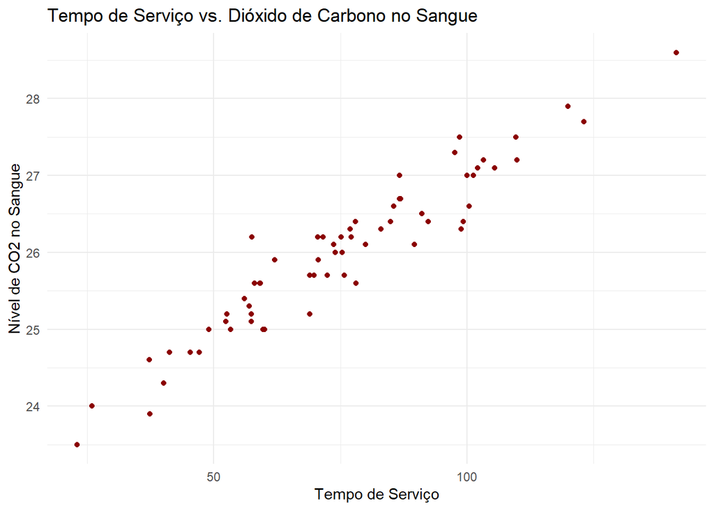

```r
ggplot(dados, aes(x = Tempo, y = Sangue)) +
  geom_point(color = "darkred") +
  labs(title = "Tempo de Serviço vs. Dióxido de Carbono no Sangue",
       x = "Tempo de Serviço",
       y = "Nível de CO2 no Sangue") +
  theme_minimal()
```

O gráfico indica uma relação linear positiva, isto é, a medida que o tempo de serviço aumenta, a quantidade de dióxido de carbono também cresce.

**b) A partir das informações amostrais e com nível de significância de 0,05, há uma relação linear entre a quantidade de dióxido de carbono e o tempo de serviço?**

**Resposta:** Para verificar se existe uma relação linear entre as variáveis, vamos calcular o teste de hipóteses para a correlação de Pearson. Segue que:

- **Hipóteses:**
  $$\left\{\begin{array}{ll}
  H_0: \rho = 0 \text{ Não há correlação linear entre as variáveis },\\
  H_1: \rho \neq 0 \text{ Há correlação linear entre as variáveis}.\\
  \end{array}\right.$$

```r
cor.test(Tempo, Sangue)
```

```
##
##  Pearson's product-moment correlation
##
## data:  Tempo and Sangue
## t = 24.491, df = 63, p-value < 2.2e-16
## alternative hypothesis: true correlation is not equal to 0
## 95 percent confidence interval:
##  0.9211031 0.9701057
## sample estimates:
##       cor
## 0.9512892
```

```r
qt(0.975, 68)
```

```
## [1] 1.995469
```

**c) Ajuste uma regressão linear simples para a relação entre as duas variáveis do estudo.**

**Resposta:**

```r
# Regressão Linear Simples
# variável dependente: dióxido de carbono no sangue
# variavel independete: tempo
# lm: linear model

modelo <- lm(Sangue ~ Tempo) # ajuste da reta de regressão de teste de hipóteses
summary(modelo)
```

```
##
## Call:
## lm(formula = Sangue ~ Tempo)
##
## Residuals:
##      Min       1Q   Median       3Q      Max
## -0.62128 -0.16789  0.02712  0.18043  0.92439
##
## Coefficients:
##              Estimate Std. Error t value Pr(>|t|)
## (Intercept) 22.989956   0.128408  179.04   <2e-16 ***
## Tempo        0.039750   0.001623   24.49   <2e-16 ***
## ---
## Signif. codes:  0 '***' 0.001 '**' 0.01 '*' 0.05 '.' 0.1 ' ' 1
##
## Residual standard error: 0.3129 on 63 degrees of freedom
## Multiple R-squared:  0.905,  Adjusted R-squared:  0.9034
## F-statistic: 599.8 on 1 and 63 DF,  p-value: < 2.2e-16
```

```r
# Calculo do IC
confint(modelo)
```

```
##                   2.5 %      97.5 %
## (Intercept) 22.73335329 23.24655846
## Tempo        0.03650706  0.04299389
```

[figure not shown]

```r
# Gráfico da Regressão
ggplot(dados, aes(x = Tempo, y = Sangue)) +
  geom_point() +
  geom_smooth(method = "lm", col = "blue") +
  labs(title = "Regressão Linear Simples entre Nível de Colesterol no Sangue  \n e Tempo de Serviço",
       x = "Nível de Colesterol",
       y = "Tempo de Serviço") +
      annotate("text", x=50, y=28, label = "y=22.99+0.04x,
              F=599.8, p-value<0.001,
               R² = 90.49%")+
  theme_minimal()
```

Para cada unidade adicional de tempo de serviço, o nível médio de dióxido de carbono no sangue aumenta, em média, 0.04 unidades. Além disso, o modelo explica cerca de 90.5% da variação dos níveis de CO2 observados.

**d) Verifique se os coeficientes são diferentes de zero, com nível de significância de 0,05. Determine o intervalo de confiança de 95% para os coeficientes. Interprete os resultados.**

**Resposta:**

Para $\alpha$: Com nível de significancia de 0.05 rejeita-se $H_0$, ou seja, o intercepto é diferente de zero ($\alpha\neq 0$). Para um trabalhador que tempo de serviço igual a zero, o nível de dióxido de carbono esperado no sangue é diferente de zero.

**Quadro ANOVA para análise de variância aplicado a regressão linear simples**

```r
summary(aov(modelo))
```

```
##             Df Sum Sq Mean Sq F value Pr(>F)
## Tempo        1  58.74   58.74   599.8 <2e-16 ***
## Residuals   63   6.17    0.10
## ---
## Signif. codes:  0 '***' 0.001 '**' 0.01 '*' 0.05 '.' 0.1 ' ' 1
```

| Causas de variação | g.l. | Soma de Quadrados | Quadrado Médio | Estat. F (Qmtrat/Qmres) | p-valor |
| --- | --- | --- | --- | --- | --- |
| Regressão | 1 | 58,74 | 58.74 | 599.8 | < 0.0001 |
| Resíduos | 63 | 6.17 | 0.10 |  |  |
| **Total** | 64 | 64.91 |  |  |  |

```r
(R2 <- (58.74/64.91 )*100)
```

```
## [1] 90.49453
```

Acima de 80% é um valor ideal, portanto, como temos 90.5% aproximadamente, o ajuste é considerado ideal.

**e) Realize a análise de resíduos para avaliar as suposições do teste utilizado no item anterior.**

**Resposta:** Vamos fazer a análise de resíduos utilizando o teste Shapiro-Wilk nos resíduos do modelo ajustado. Segue que,

- **Hipoteses:**
  $$\left\{\begin{array}{ll}
  H_0:\text{ Resíduos tem distribuição Normal },\\
  H_1: \text{ Resíduos não tem distribuição Normal.}.\\
  \end{array}\right.$$

```r
# analise de resíduos
residuos <- modelo$residuals
shapiro.test(residuos)
```

```
##
##  Shapiro-Wilk normality test
##
## data:  residuos
## W = 0.98091, p-value = 0.4131
```

- **Nível de significância de 0.05:** p-value = 0.4131
- **Estatística do teste:** W=0.98091
- **Conclusão:** com nível de significancia de 0.05, não rejeita-se $H_0$, ou seja, os resíduos da reta de regressão estimada possuem distribuição Normal.

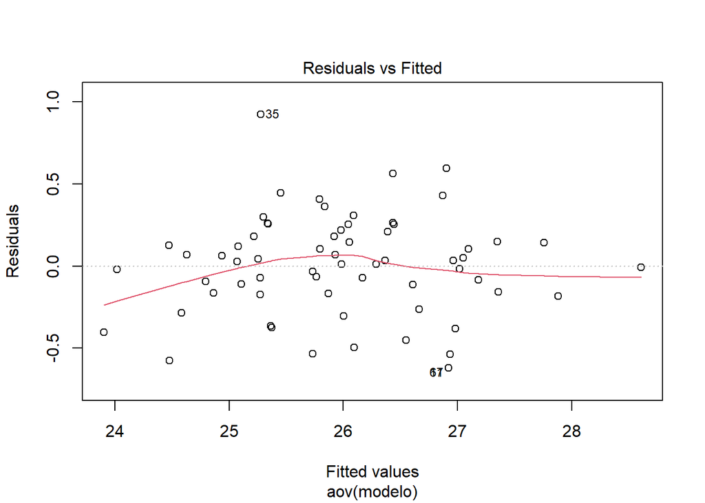

```r
anova<- aov(modelo)
plot(anova, 1) # avalia os valores ajustados com os resíduos
```

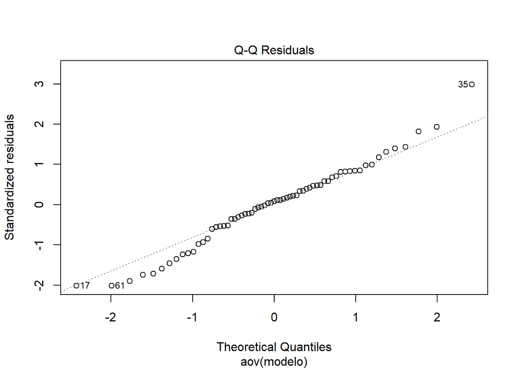

```r
plot(anova, 2) # avalia os resíduos
```

```r
dados[c(17,35,61),]
```

| Tempo | Sangue |
| --- | --- |
| 98.9 | 26.3 |
| 57.5 | 26.2 |
| 98.9 | 26.3 |

Os resíduos apresentam distribuição aproximadamente normal e não há padrão sistemático aparente, indicando que as suposições do modelo linear foram atendidas. Assim, o modelo é adequado para descrever a relação entre o tempo de serviço e o nível de dióxido de carbono no sangue. Existem 3 valores discrepantes que são interessantes de serem avaliados, a saber os exames de número 17, 35 e 61, por serem outliers nas caldas da distribuição dos resíduos.

**2) Uma pesquisa avaliou pacientes com câncer em um grande hospital. Utilizando as informações de uma amostra de pacientes sobre o estadiamento da doença e o tempo de sobrevida, em meses, determine:**

```r
dadosATV2 <- read_excel("dados.xlsx", sheet = "AtividadeEx2")
head(dadosATV2)
```

| Estadiamento | Tempo de sobrevida em meses |
| --- | --- |
| II | 27.6 |
| III | 27.3 |
| III | 34.3 |
| IV | 14.0 |
| II | 33.5 |
| III | 25.7 |

```r
attach(dadosATV2)
Sobrevida <- `Tempo de sobrevida em meses` # mudando a variável

summary(dadosATV2)
```

```
##  Estadiamento       Tempo de sobrevida em meses
##  Length:50          Min.   :14.00
##  Class :character   1st Qu.:24.35
##  Mode  :character   Median :27.30
##                     Mean   :27.63
##                     3rd Qu.:31.50
##                     Max.   :40.90
```

**a) O gráfico de dispersão entre as duas variáveis do estudo.**

**Resposta:** Neste estudo temos duas variáveis distintas:

Como temos uma variável categórica (Estadiamento), o gráfico mais apropriado para visualizar a relação entre as variáveis é o boxplot.

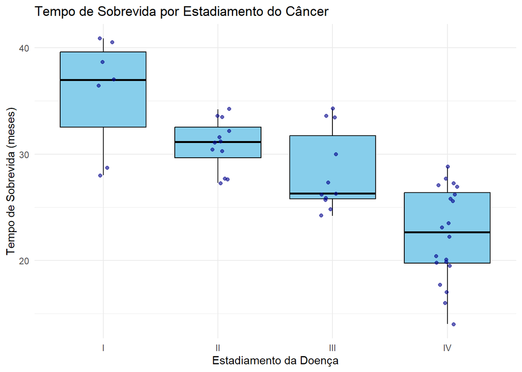

```r
ggplot(dadosATV2, aes(x = Estadiamento, y = Sobrevida)) +
  geom_boxplot(fill = "skyblue", color = "black") +
  geom_jitter(width = 0.1, alpha = 0.6, color = "darkblue") +
  labs(title = "Tempo de Sobrevida por Estadiamento do Câncer",
       x = "Estadiamento da Doença",
       y = "Tempo de Sobrevida (meses)") +
  theme_minimal()
```

Cada boxplot representa a distribuição dos tempos de sobrevida dentro de cada estadiamento.

- Estágio I: apresenta as maiores medianas e amplitudes, com tempos de sobrevida geralmente acima de 35 meses, indicando pacientes em estágio inicial com melhor prognóstico.
- Estágio II: apresenta uma leve redução da mediana, em torno de 31 meses;
- Estágio III: a mediana diminui ainda mais e há maior dispersão, indicando mais variabilidade do avanço da doença;
- Estágia IV: apresenta a menor mediana e menores tempos de sobrevida, reforçando o efeito negativo do avanço da doença.

**b) Se há uma relação entre as duas variáveis, com nível de significância de 0,05.**

**Resposta:** Verificando a Normalidade das variáveis com Shapiro-Wilk separadamente para os pacientes de cada estadiamento. Temos que

- **Hipóteses:**
  $$\left\{\begin{array}{ll}
  H_0:\text{ Os dados do grupo seguem distribuição Normal },\\
  H_1: \text{ Os dados do grupo não seguem distribuição Normal.}.\\
  \end{array}\right.$$

```r
# Teste de normalidade dentro de cada estadiamento
by(dadosATV2$`Tempo de sobrevida em meses`, dadosATV2$Estadiamento, shapiro.test)
```

```
## dadosATV2$Estadiamento: I
##
##  Shapiro-Wilk normality test
##
## data:  dd[x, ]
## W = 0.84066, p-value = 0.1008
##
## ------------------------------------------------------------
## dadosATV2$Estadiamento: II
##
##  Shapiro-Wilk normality test
##
## data:  dd[x, ]
## W = 0.91987, p-value = 0.2849
##
## ------------------------------------------------------------
## dadosATV2$Estadiamento: III
##
##  Shapiro-Wilk normality test
##
## data:  dd[x, ]
## W = 0.83464, p-value = 0.02686
##
## ------------------------------------------------------------
## dadosATV2$Estadiamento: IV
##
##  Shapiro-Wilk normality test
##
## data:  dd[x, ]
## W = 0.94298, p-value = 0.2728
```

Como resultado do teste de normalidade, temos

| Estadiamento | W | p-valor | Conclusão ($\alpha = 0.05)$ |
| --- | --- | --- | --- |
| I | 0.8407 | 0.1008 | Não rejeita ($H_0$): normal |
| II | 0.9199 | 0.2849 | Não rejeita ($H_0$): normal |
| III | 0.8346 | **0.0269** | Rejeita ($H_0$): não normal |
| IV | 0.9430 | 0.2728 | Não rejeita ($H_0$): normal |

**Conclusão:** Como o grupo de estadiamento nível III não apresenta distribuição Normal, a suposição de normalidade não é atendida para todos os grupos.

Portanto, vamos utilizar o teste não-paramétrico de Kruskal-Wallis. Segue que:

- **Hipóteses:**
  $$\left\{\begin{array}{ll}
  H_0:\text{ As distribuições de sobrevida são iguais entre os
  estadiamentos },\\
  H_1: \text{ Pelo menos uma distribuição difere}.\\
  \end{array}\right.$$

```r
kruskal.test(`Tempo de sobrevida em meses` ~ Estadiamento, data = dadosATV2)
```

```
##
##  Kruskal-Wallis rank sum test
##
## data:  Tempo de sobrevida em meses by Estadiamento
## Kruskal-Wallis chi-squared = 30.521, df = 3, p-value = 1.072e-06
```

- **Nível de significância de 0.05:** p-value < 0.0001.
- **Estatística do teste:** 30.521 com gl = 3.
- **Conclusão:** com nível de significancia de 0.05, rejeita-se $H_0$, há diferença estatisticamente significativa nos tempos de sobrevida entre os diferentes estadiamentos do câncer.

Finalmente, vamos fazer as comparações multiplas e observar diferenças entre os estadiamentos, considerando que um dos grupos não tem dstribuição Normal. Vamos identificar entre quais pares de estadiamento existem diferenças significativas.

- **Hipóteses:**
  $$\left\{\begin{array}{ll}
  H_0:\text{ As medianas de sobrevida dos dois grupos são iguais },\\
  H_1: \text{ As medianas de sobrevida dos dois grupos são diferentes}.\\
  \end{array}\right.$$

```r
library(pgirmess)
kruskalmc(Sobrevida~Estadiamento)
```

```
## Multiple comparison test after Kruskal-Wallis
## alpha: 0.05
## Comparisons
##          obs.dif critical.dif stat.signif
## I-II    7.458333     18.29084       FALSE
## I-III  16.863636     18.59463       FALSE
## I-IV   30.000000     16.88941        TRUE
## II-III  9.405303     16.05364       FALSE
## II-IV  22.541667     14.04320        TRUE
## III-IV 13.136364     14.43664       FALSE
```

```r
(tapply(Sobrevida, Estadiamento, median))
```

```
##     I    II   III    IV
## 37.00 31.15 26.30 22.65
```

- **Nível de significância:** $\alpha = 0.05$.
- **Resultados do teste de comparação múltiplas:**

| Comparação | Diferença observada | Diferença crítica | Decisão ($\alpha=0.05$) | Conclusão |
| --- | --- | --- | --- | --- |
| I - II | 7.46 | 18.29 | Não rejeita ($H_0$) | Mesma mediana de sobrevida |
| I - III | 16.86 | 18.59 | Não rejeita ($H_0$) | Mesma mediana de sobrevida |
| **I - IV** | **30.00** | **16.89** | **Rejeita** ($H_0$) | IV tem menor sobrevida que I |
| II - III | 9.41 | 16.05 | Não rejeita ($H_0$) | Mesma mediana de sobrevida |
| **II - IV** | **22.54** | **14.04** | **Rejeita** ($H_0$) | IV tem menor sobrevida que II |
| III - IV | 13.14 | 14.44 | Não rejeita ($H_0$) | Mesma mediana de sobrevida |

**Conclusão:** Com nível de signficância de 0.05, o teste de Kruskal-Wallis indicou diferença significativa entre os tempos de sobrevida dos diferentes estadiamentos. As comparações múltiplas mostraram que as diferenças ocorrem entre os estágios iniciais (I e II) e o estágio IV, sendo este último associado a menor tempo de sobrevida. Não foram observadas diferenças significativas entre os estágios intermediários (II vs III, III vs IV ou I vs III.)